# Fitting the CMA Model to Kaggle Brist1D CGM Data

Reference: https://www.kaggle.com/competitions/brist1d/data

## Dataset description (from Kaggle)

The dataset is from a study that collected data from young adults in the UK with type 1 diabetes, who used a continuous glucose monitor (CGM), an insulin pump and a smartwatch. These devices collected blood glucose readings, insulin dosage, carbohydrate intake, and activity data. The data collected was aggregated to five-minute intervals and formatted into samples. Each sample represents a point in time and includes the aggregated five-minute intervals from the previous six hours. The aim is to predict the blood glucose reading an hour into the future, for each of these samples.

The training set takes samples from the first three months of study data from nine of the participants and includes the future blood glucose value. These training samples appear in chronological order and overlap. The testing set takes samples from the remainder of the study period from fifteen of the participants (so unseen participants appear in the testing set). These testing samples do not overlap and are in a random order to avoid data leakage.

**Complexities to be aware of:**

- this is medical data so there are missing values and noise in the data
- the participants did not all use the same device models (CGM, insulin pump and smartwatch) so there may be differences in the collection method of the data
- some participants in the test set do not appear in the training set

```python
#%%sh

### Install dependencies for conda:

# nix-shell -p micromamba

# micromamba install -c conda-forge ipykernel pandas --force-reinstall
#"$HOME/.nix-profile/bin/micromamba" run pip install -e '../../' --upgrade --force-reinstall
```

## Load the Kaggle Brist1D Dataset

```python
import pandas as pd
import numpy as np
from pfun_cma_model.misc.pathdefs import PFunDataPaths
import duckdb
from datetime import datetime
import logging
logger = logging.getLogger()
logger.setLevel(logging.INFO)

# Ensure your kaggle.json is correctly configured before running this command
# We use the built-in paths helper to download the Brist1D dataset via the Kaggle API and save it as a fast Parquet file
paths = PFunDataPaths()
paths.download_kaggle_brist1d(overwrite=True)

# Load CGM data from the downloaded Brist1D dataset
df = pd.read_parquet(paths.brist1d_data_fpath)
df
```

[output not shown]

```
2026-04-22 14:06:47 [INFO] pfun-cma-model-app: Converting downloaded CSV to Parquet using DuckDB...
2026-04-22 14:06:50 [INFO] pfun-cma-model-app: Successfully converted and saved to /home/robbiec/Git/pfun-cma-model/.venv/lib/python3.12/site-packages/pfun_common/data/brist1d_train.parquet.
```

|  | id | p_num | time | bg-5:55 | bg-5:50 | bg-5:45 | bg-5:40 | bg-5:35 | bg-5:30 | bg-5:25 | ... | activity-0:40 | activity-0:35 | activity-0:30 | activity-0:25 | activity-0:20 | activity-0:15 | activity-0:10 | activity-0:05 | activity-0:00 | bg+1:00 |
| --- | --- | --- | --- | --- | --- | --- | --- | --- | --- | --- | --- | --- | --- | --- | --- | --- | --- | --- | --- | --- | --- |
| 0 | p01_0 | p01 | 06:10:00 | NaN | NaN | 9.6 | NaN | NaN | 9.7 | NaN | ... | NaN | NaN | NaN | NaN | NaN | NaN | NaN | NaN | NaN | 13.4 |
| 1 | p01_1 | p01 | 06:25:00 | NaN | NaN | 9.7 | NaN | NaN | 9.2 | NaN | ... | NaN | NaN | NaN | NaN | NaN | NaN | NaN | NaN | NaN | 12.8 |
| 2 | p01_2 | p01 | 06:40:00 | NaN | NaN | 9.2 | NaN | NaN | 8.7 | NaN | ... | NaN | NaN | NaN | NaN | NaN | NaN | NaN | NaN | NaN | 15.5 |
| 3 | p01_3 | p01 | 06:55:00 | NaN | NaN | 8.7 | NaN | NaN | 8.4 | NaN | ... | NaN | NaN | NaN | NaN | NaN | NaN | NaN | NaN | NaN | 14.8 |
| 4 | p01_4 | p01 | 07:10:00 | NaN | NaN | 8.4 | NaN | NaN | 8.1 | NaN | ... | NaN | NaN | NaN | NaN | NaN | NaN | NaN | NaN | NaN | 12.7 |
| ... | ... | ... | ... | ... | ... | ... | ... | ... | ... | ... | ... | ... | ... | ... | ... | ... | ... | ... | ... | ... | ... |
| 177019 | p12_25294 | p12 | 23:35:00 | 8.8 | 9.1 | 9.2 | 9.4 | 9.8 | 10.2 | 10.4 | ... | NaN | NaN | NaN | NaN | NaN | NaN | NaN | NaN | NaN | 11.1 |
| 177020 | p12_25295 | p12 | 23:40:00 | 9.1 | 9.2 | 9.4 | 9.8 | 10.2 | 10.4 | 10.3 | ... | NaN | NaN | NaN | NaN | NaN | NaN | NaN | NaN | NaN | 10.9 |
| 177021 | p12_25296 | p12 | 23:45:00 | 9.2 | 9.4 | 9.8 | 10.2 | 10.4 | 10.3 | 10.1 | ... | NaN | NaN | NaN | NaN | NaN | NaN | NaN | NaN | NaN | 10.7 |
| 177022 | p12_25297 | p12 | 23:50:00 | 9.4 | 9.8 | 10.2 | 10.4 | 10.3 | 10.1 | 10.0 | ... | NaN | NaN | NaN | NaN | NaN | NaN | NaN | NaN | NaN | 10.5 |
| 177023 | p12_25298 | p12 | 23:55:00 | 9.8 | 10.2 | 10.4 | 10.3 | 10.1 | 10.0 | 9.8 | ... | NaN | NaN | NaN | NaN | NaN | NaN | NaN | NaN | NaN | 10.2 |

177024 rows × 508 columns

## Preprocess the data

The model requires 'time' in UTC format, and typically 'G' (glucose) and 'sg' (sensor glucose) columns

```python
from typing import Sequence

# For this example, we will focus on a single participant's continuous glucose trace
participant_df = df[df['p_num'] == 'p01'].copy().reset_index(drop=True)

def create_synthetic_datetime(time: pd.Series) -> Sequence['datetime64[us, UTC]']:
    today_string = pd.Timestamp.today().strftime('%Y-%m-%d')
    datetime_string = today_string + ' ' + time.astype(str)
    datetime_vector = pd.to_datetime(datetime_string).dt.tz_localize('UTC')
    return datetime_vector

participant_df['time'] = create_synthetic_datetime(participant_df["time"])
participant_df['displayTime'] = participant_df['time']
participant_df['systemTime'] = participant_df['time']
participant_df['G'] = participant_df['bg+1:00']
participant_df['sg'] = participant_df['bg+1:00']
cgm_data = participant_df[['time', 'G', 'sg']]

# Checking the structure of the loaded data
print(cgm_data.head(), end="\n")

print("Shape:\n", cgm_data.shape, end="\n")

print("Data types:\n", cgm_data.dtypes, end="\n")

print(cgm_data.describe(), end="\n")
```

```
                       time     G    sg
0 2026-04-22 06:10:00+00:00  13.4  13.4
1 2026-04-22 06:25:00+00:00  12.8  12.8
2 2026-04-22 06:40:00+00:00  15.5  15.5
3 2026-04-22 06:55:00+00:00  14.8  14.8
4 2026-04-22 07:10:00+00:00  12.7  12.7
Shape:
 (8459, 3)
Data types:
 time    datetime64[us, UTC]
G                   float64
sg                  float64
dtype: object
                 G           sg
count  8459.000000  8459.000000
mean      8.888781     8.888781
std       4.132187     4.132187
min       2.200000     2.200000
25%       5.600000     5.600000
50%       8.100000     8.100000
75%      11.500000    11.500000
max      27.800000    27.800000
```

## Plot the selected CGM data (p01)

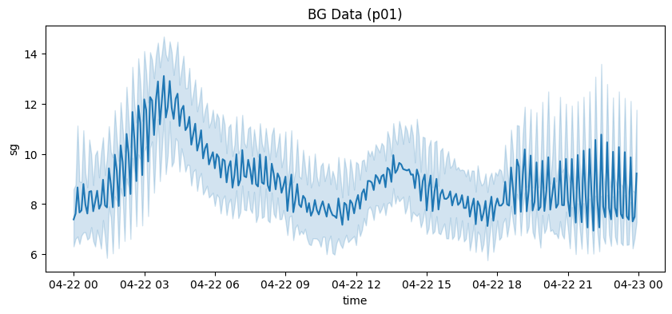

```python
from pfun_common.plot import lineplot as pfun_lineplot

ax = pfun_lineplot(cgm_data, tcol="time", ycol="sg")
ax.set_title("BG Data (p01)")
ax.figure.set_size_inches(10, 4)
```

## Perform the model fit

- Our fitting procedure is sensitive to periodic noise.
- Some hyperparameter optimization will help find an ROI in the parameter space.

```python
#from scipy.optimize import minimize
from pfun_cma_model.engine.fit import fit_model

# Fit the model to the CGM data

# Bounds-constrained minimization:
#   Nelder-Mead, L-BFGS-B, TNC, SLSQP, Powell

algorithms = (
    "Nelder-Mead",
    "L-BFGS-B",
    "TNC",
    "SLSQP",
    "Powell"
)

residuals = {}

def get_residual(result) -> float:
    residual = result.infodict["result"].fun
    return residual

for N in (24, 48, 128, 256, 512, 1024):
    for tm_freq in ('1h', '2h', '4h', '8h'):
        for algo in algorithms:
            try:
                result = fit_model(
                    cgm_data,
                    tcol='time',
                    ycol='G',
                    tm_freq=tm_freq,
                    N=N,
                    curve_fit_kwargs={
                        "method": f"{algo}",
                    }
                )
            except RuntimeError as exception:
                logging.warning(
                    "\n({%s %s, %s) Failed to converge.",
                    N, algo, tm_freq,
                    exc_info=False
                )
            else:
                result_key = (N, algo, tm_freq)
                residual = get_residual(result)
                residuals[result_key] = result
                print(f"{str(result_key)} residual = {residual:.4f}")
```

```
(24, 'Nelder-Mead', '1h') residual = 0.0037
(24, 'L-BFGS-B', '1h') residual = 0.0037
(24, 'TNC', '1h') residual = 0.0037
(24, 'SLSQP', '1h') residual = 0.0037
(24, 'Powell', '1h') residual = 0.0037
(24, 'Nelder-Mead', '2h') residual = 0.0094
(24, 'L-BFGS-B', '2h') residual = 0.0094
(24, 'TNC', '2h') residual = 0.0094
(24, 'SLSQP', '2h') residual = 0.0094
(24, 'Powell', '2h') residual = 0.0094
(24, 'Nelder-Mead', '4h') residual = 0.0109
(24, 'L-BFGS-B', '4h') residual = 0.0109
(24, 'TNC', '4h') residual = 0.0109
(24, 'SLSQP', '4h') residual = 0.0109
(24, 'Powell', '4h') residual = 0.0109
(24, 'Nelder-Mead', '8h') residual = 0.5054
(24, 'L-BFGS-B', '8h') residual = 0.5054
(24, 'TNC', '8h') residual = 0.5054
(24, 'SLSQP', '8h') residual = 0.5054
(24, 'Powell', '8h') residual = 0.5054
2026-04-22 14:07:38 [WARNING] root:
({48 Nelder-Mead, 1h) Failed to converge.
2026-04-22 14:07:40 [WARNING] root:
({48 L-BFGS-B, 1h) Failed to converge.
2026-04-22 14:07:43 [WARNING] root:
({48 TNC, 1h) Failed to converge.
2026-04-22 14:07:46 [WARNING] root:
({48 SLSQP, 1h) Failed to converge.
2026-04-22 14:07:49 [WARNING] root:
({48 Powell, 1h) Failed to converge.
2026-04-22 14:07:51 [WARNING] root:
({48 Nelder-Mead, 2h) Failed to converge.
2026-04-22 14:07:52 [WARNING] root:
({48 L-BFGS-B, 2h) Failed to converge.
2026-04-22 14:07:54 [WARNING] root:
({48 TNC, 2h) Failed to converge.
2026-04-22 14:07:55 [WARNING] root:
({48 SLSQP, 2h) Failed to converge.
2026-04-22 14:07:57 [WARNING] root:
({48 Powell, 2h) Failed to converge.
```

[output cut: 100 more lines]

[output not shown]

```
Algorithm: '(24, 'Nelder-Mead', '1h')' (0.004)
Model Parameters:
{'d': np.float64(10.998074926197315), 'taup': np.float64(204.79132706005993), 'taug': np.float64(0.47980316358899894), 'B': np.float64(0.13089160849291048), 'Cm': np.float64(-0.02065903924821594), 'toff': np.float64(17.5474213585882)}

Model Fit Results Info:
{'message': 'Optimization terminated successfully.', 'error': None, 'ier': 0, 'result':   message: CONVERGENCE: NORM OF PROJECTED GRADIENT <= PGTOL
  success: True
   status: 0
      fun: 0.0036699397923638053
        x: [ 1.100e+01  2.048e+02  4.798e-01  1.309e-01 -2.066e-02
             1.755e+01]
      nit: 98
      jac: [-3.860e-09 -4.293e-09  2.251e-08  2.414e-06  1.209e-07
             5.603e-08]
     nfev: 1078
     njev: 154
 hess_inv: <6x6 LbfgsInvHessProduct with dtype=float64>}
Optimization terminated successfully.
```

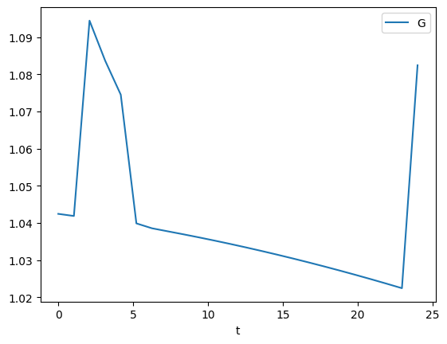

```python
best_algorithm, model_results = min(residuals.items(), key=lambda pair: get_residual(pair[1]))
best_residual = get_residual(model_results)
print(f"Algorithm: '{best_algorithm}' ({best_residual:.3f})")

model_results.soln.head()
model_results.soln.plot(x="t", y="G")

print("Model Parameters:")
print(model_results.popt_named)
print("\nModel Fit Results Info:")
print(model_results.infodict)
print(model_results.infodict['message'])
```

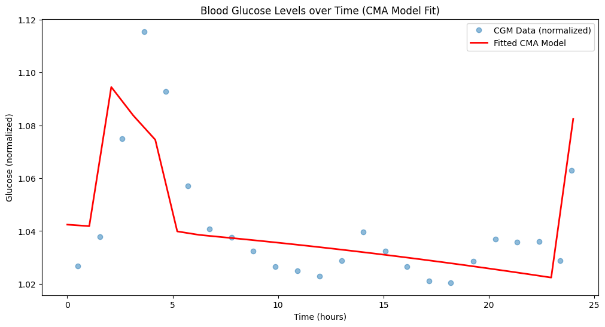

```python
# Displaying results
import matplotlib.pyplot as plt

plt.figure(figsize=(12, 6))
# Use formatted_data for normalized raw glucose values (scaled to [0, 2])
plt.plot(model_results.formatted_data['t'], model_results.formatted_data['G'], label='CGM Data (normalized)', marker='o', linestyle='none', alpha=0.5)

# The model_results.soln dataframe contains the fitted curve (indexed by timedelta in hours)
plt.plot(model_results.soln["t"], model_results.soln['G'], label='Fitted CMA Model', color='red', linewidth=2)

plt.title('Blood Glucose Levels over Time (CMA Model Fit)')
plt.xlabel('Time (hours)')
plt.ylabel('Glucose (normalized)')
plt.legend()
plt.show()
```

## Posthoc Analysis

The PFun CMA model effectively characterizes the dynamic continuous glucose monitor (CGM) traces by adjusting specific physiological parameters (`taup`, `taug`, `Cm`).

**Key Highlights:**

- The fitting process expects timestamp columns (`time` by default) in **UTC** format, which we handled by appending arbitrary UTC dates to the `HH:MM:SS` time values provided in the competition dataset.
- Additional preprocessing steps are often handled directly through `fit_model` calling `format_data`.
- By observing the parameter bounds and bounds conditions, one can tune the CMA model further to adjust to real physiological profiles seen across different participants.